# Practical Machine Learning Project

DR

06 de diciembre de 2019

# Introduction

Using devices such as Jawbone Up, Nike FuelBand, and Fitbit it is now possible to collect a large amount of data about personal activity relatively inexpensively. These type of devices are part of the quantified self movement â a group of enthusiasts who take measurements about themselves regularly to improve their health, to find patterns in their behavior, or because they are tech geeks. One thing that people regularly do is quantify how much of a particular activity they do, but they rarely quantify how well they do it. In this project, your goal will be to use data from accelerometers on the belt, forearm, arm, and dumbell of 6 participants. They were asked to perform barbell lifts correctly and incorrectly in 5 different ways. More information is available from the website here: http://web.archive.org/web/20161224072740/http:/groupware.les.inf.puc-rio.br/har (see the section on the Weight Lifting Exercise Dataset).

# The Datasets

Let’s read the datasets and see how the look like

```r
data<-read.csv("pml-training.csv")
validation<-read.csv("pml-testing.csv")

dim(data)
```

```
## [1] 19622   160
```

```r
dim(validation)
```

```
## [1]  20 160
```

```r
summary(data)
```

[output not shown]

[output cut: 313 more lines]

```
##  Min.   :-446.00   Min.   :-1280.0   Min.   :-896.0   Min.   :-973.0
##  1st Qu.:-182.00   1st Qu.: -616.0   1st Qu.:   2.0   1st Qu.: 191.0
##  Median : -39.00   Median : -378.0   Median : 591.0   Median : 511.0
##  Mean   : -55.29   Mean   : -312.6   Mean   : 380.1   Mean   : 393.6
##  3rd Qu.:  26.00   3rd Qu.:  -73.0   3rd Qu.: 737.0   3rd Qu.: 653.0
##  Max.   : 291.00   Max.   :  672.0   Max.   :1480.0   Max.   :1090.0
##
##  classe
##  A:5580
##  B:3797
##  C:3422
##  D:3216
##  E:3607
##
##
```

```r
summary(validation)
```

[output not shown]

[output cut: 289 more lines]

```
##  Min.   :-1.2600   Min.   :-212.0   Min.   :-331.0   Min.   :-282.0
##  1st Qu.:-0.0975   1st Qu.:-114.8   1st Qu.:   8.5   1st Qu.:-199.0
##  Median : 0.2300   Median :  86.0   Median : 138.0   Median :-148.5
##  Mean   : 0.2610   Mean   :  38.8   Mean   : 125.3   Mean   : -93.7
##  3rd Qu.: 0.7625   3rd Qu.: 166.2   3rd Qu.: 268.0   3rd Qu.: -31.0
##  Max.   : 1.8000   Max.   : 232.0   Max.   : 406.0   Max.   : 179.0
##
##  magnet_forearm_x magnet_forearm_y magnet_forearm_z   problem_id
##  Min.   :-714.0   Min.   :-787.0   Min.   :-32.0    Min.   : 1.00
##  1st Qu.:-427.2   1st Qu.:-328.8   1st Qu.:275.2    1st Qu.: 5.75
##  Median :-189.5   Median : 487.0   Median :491.5    Median :10.50
##  Mean   :-159.2   Mean   : 191.8   Mean   :460.2    Mean   :10.50
##  3rd Qu.:  41.5   3rd Qu.: 720.8   3rd Qu.:661.5    3rd Qu.:15.25
##  Max.   : 532.0   Max.   : 800.0   Max.   :884.0    Max.   :20.00
##
```

As shown above there are 19622 observations and 160 variables in the Training dataset. In the other hand, in the Validation dataset there are 20 observations and 160 variables.

# Cleaning the input data

Next, the data were cleaned specifically, irrelevant columns (including those with numerous NA values) were removed from the datasets.

```r
#identify columns where the values are NA within the training dataset
missingDataTrainingDataSet<-colnames(data)[colSums(is.na(data)) > 0 ]

#remove these columns from the training dataset:
data<-data[,!(names(data) %in% missingDataTrainingDataSet)]

#need to do the same thing for the validation dataset using column names from training dataset:
validation<-validation[,!(names(validation) %in% missingDataTrainingDataSet)]

#We should also check to see if there are columns where the values are NA in the validation dataset as well:
missingDataValidationDataSet<-colnames(validation)[colSums(is.na(validation)) > 0 ]

#remove these columns from the testing dataset:
validation<-validation[,!(names(validation) %in% missingDataValidationDataSet)]

#There are another columns within the testing dataset where the values are NA. Will remove these from the training dataset.
data<-data[,!(names(data) %in% missingDataValidationDataSet)]

#lastly, we're going to remove the first 7 columns of the dataset since they're irrelevant variables for the analysis:
data<-data[,-c(1:7)]
validation<-validation[,-c(1:7)]

#Because this dataset is large (19622 x 160), and a "validation" dataset is supplied I'm dividing the data into a a 60/40 split
set.seed(1234)
inTrain <- createDataPartition(y=data$classe, p=0.6, list=FALSE)
training <- data[inTrain,]
testing <- data[-inTrain,]

dim(training)
```

```
## [1] 11776    53
```

```r
dim(testing)
```

```
## [1] 7846   53
```

```r
dim(validation)
```

```
## [1] 20 53
```

After all three datasets were cleaned of irrelevant predictor variables, the dimensions were 11776 x 53, 7846 x 53, and 20 x 53 for the training, testing, and validation datasets,respectively.

The following correlation plot uses the following parameters “FPC”: the first principal component order. “AOE”: the angular order tl.cex Numeric, for the size of text label (variable names) tl.col The color of text label.

In the corrplot graph the correlated predictors (variables ) are those with a dark color intersection.

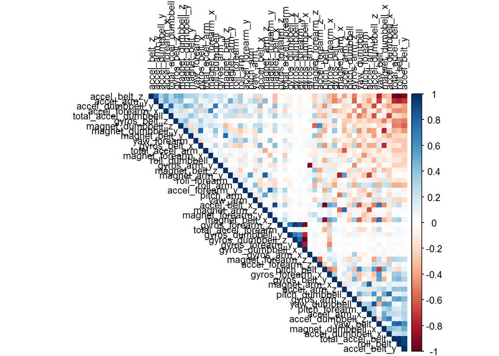

```r
cor_mat <- cor(training[, -53])
corrplot(cor_mat, order = "FPC", method = "color", type = "upper",
         tl.cex = 0.8, tl.col = rgb(0, 0, 0))
```

To obtain the names of the variables we use the findCorrelation function to search for highly correlated attributes with a cut off equal to 0.75

```r
highlyCorrelated = findCorrelation(cor_mat, cutoff=0.75)
names(training)[highlyCorrelated]
```

```
##  [1] "accel_belt_z"      "roll_belt"         "accel_belt_y"
##  [4] "total_accel_belt"  "accel_dumbbell_z"  "accel_belt_x"
##  [7] "pitch_belt"        "magnet_dumbbell_x" "accel_dumbbell_y"
## [10] "magnet_dumbbell_y" "accel_dumbbell_x"  "accel_arm_x"
## [13] "accel_arm_z"       "magnet_arm_y"      "magnet_belt_z"
## [16] "accel_forearm_y"   "gyros_forearm_y"   "gyros_dumbbell_x"
## [19] "gyros_dumbbell_z"  "gyros_arm_x"
```